# MCC Preference Kids

Manuel Bohn

23 7 2018

# Subjects

There was one additional 4yo in the data set, whom I excluded to get the pre-registered sample size of 45 total. For the modeling we might want to include her as that gives us a tiny bit more precision.

## Overall

All training trials were answered correctly, suggesting that children generally understood the procedure. Sex is not included in the data set but the sex ration is fairly balances across age bins (47 to 60% girls).

| trial_type | n | correct |
| --- | --- | --- |
| test | 45 | 0.56 |
| train | 45 | 1.00 |

## By age bin

Just to check if we got the planned sample size of 15 per bin.

| age | n | age_num |
| --- | --- | --- |
| 2 | 15 | 2.49 |
| 3 | 15 | 3.63 |
| 4 | 15 | 4.40 |

# Plots

## Plot across age bins

Medium overall effect of speaker change.

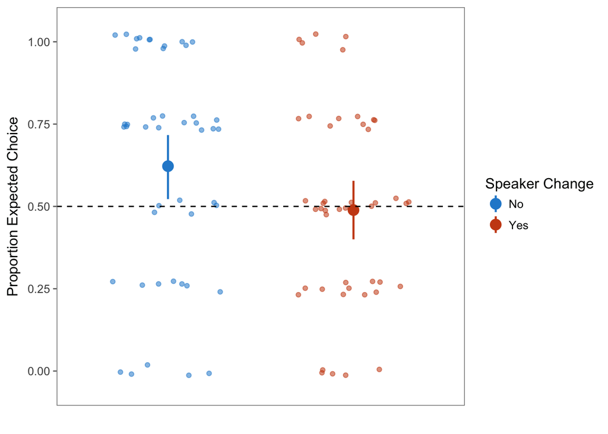

## Plot by age bin

The following two plots suggest some sort of linear developmental trajectory.

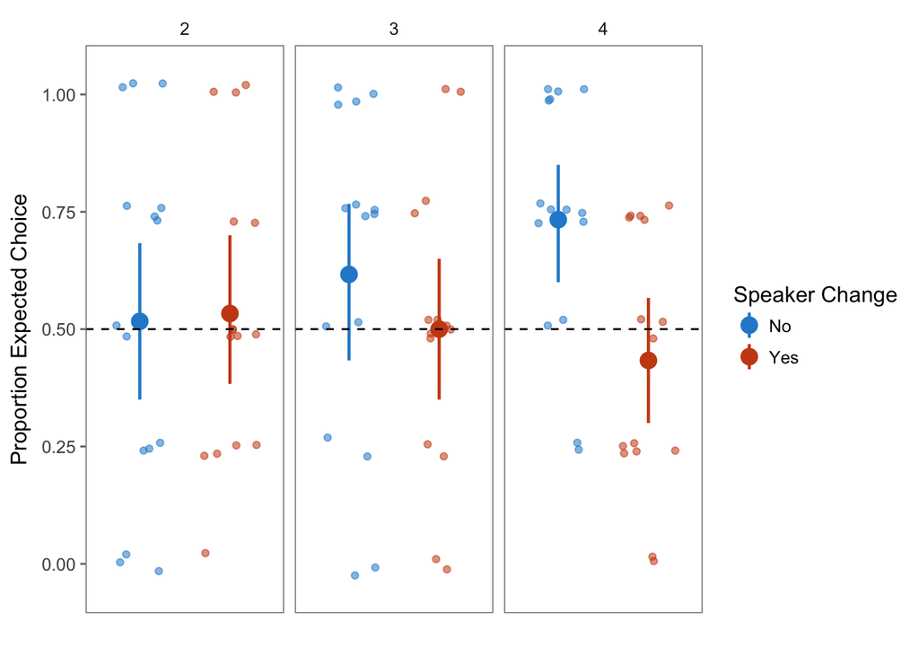

## Plot with age as continuous variable

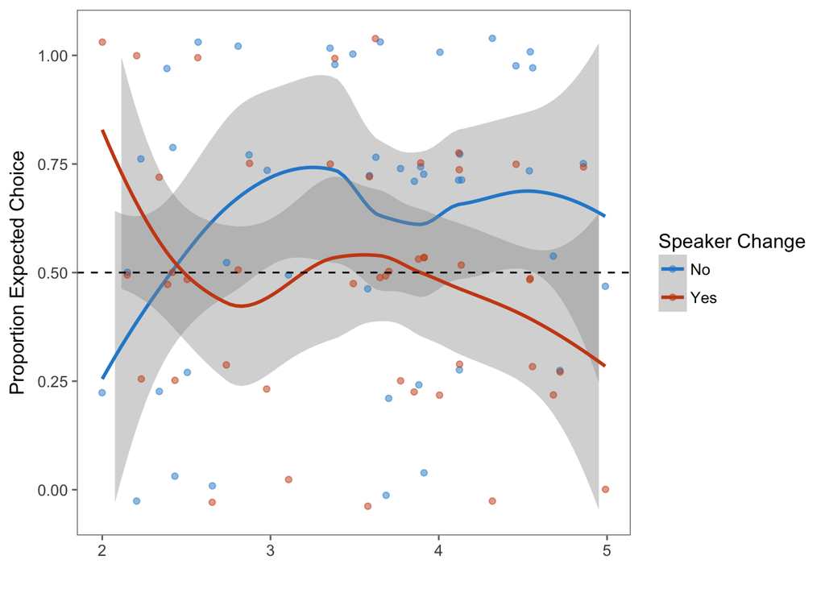

# Inference

## T-tests against chance across age bins

| change | df | t_value | p_value |
| --- | --- | --- | --- |
| false | 44 | 2.444 | 0.019 |
| true | 44 | -0.256 | 0.800 |

## T-tests against chance per age bin

| age | change | df | t_value | p_value |
| --- | --- | --- | --- | --- |
| 2 | false | 14 | 0.174 | 0.865 |
| 2 | true | 14 | 0.414 | 0.685 |
| 3 | false | 14 | 1.284 | 0.220 |
| 3 | true | 14 | 0.000 | 1.000 |
| 4 | false | 14 | 3.500 | 0.004 |
| 4 | true | 14 | -0.939 | 0.364 |

## GLMM

With age as continuous variable. We pre-registered the model with an interaction between age and change as a random slope for subject: `(change * age| subid)`. However, including age here seems unnecessary since each subject has only one age. I therefore took the interaction out in the model below.

Results mirror what we see in the plots above: increasing effect of speaker change across development.

```
## Generalized linear mixed model fit by maximum likelihood (Laplace
##   Approximation) [glmerMod]
##  Family: binomial  ( logit )
## Formula:
## correct ~ age_num * change + (change | subid) + (age_num * change |
##     choiceAgent)
##    Data: lm_data
## Control:
## glmerControl(optimizer = "bobyqa", optCtrl = list(maxfun = 2e+05))
##
##      AIC      BIC   logLik deviance df.resid
##    493.7    559.7   -229.8    459.7      343
##
## Scaled residuals:
##     Min      1Q  Median      3Q     Max
## -1.8838 -0.8062  0.3646  0.7601  1.5070
##
## Random effects:
##  Groups      Name               Variance  Std.Dev. Corr
##  subid       (Intercept)        2.0647344 1.43692
##              changetrue         1.5733124 1.25432  -0.90
##  choiceAgent (Intercept)        0.0258830 0.16088
##              age_num            0.4867549 0.69768   1.00
##              changetrue         0.0008862 0.02977   1.00  1.00
##              age_num:changetrue 0.3036551 0.55105  -1.00 -1.00 -1.00
## Number of obs: 360, groups:  subid, 45; choiceAgent, 12
##
## Fixed effects:
##                    Estimate Std. Error z value Pr(>|z|)
## (Intercept)          0.7109     0.2968   2.396   0.0166 *
## age_num              0.4395     0.3540   1.242   0.2144
## changetrue          -0.7622     0.3177  -2.399   0.0164 *
## age_num:changetrue  -0.7091     0.3563  -1.990   0.0466 *
## ---
## Signif. codes:  0 '***' 0.001 '**' 0.01 '*' 0.05 '.' 0.1 ' ' 1
##
## Correlation of Fixed Effects:
##             (Intr) age_nm chngtr
## age_num      0.124
## changetrue  -0.804 -0.023
## ag_nm:chngt -0.107 -0.853  0.035
```

# Additional plots

To check for trial and item effects.

## Conditions by trial

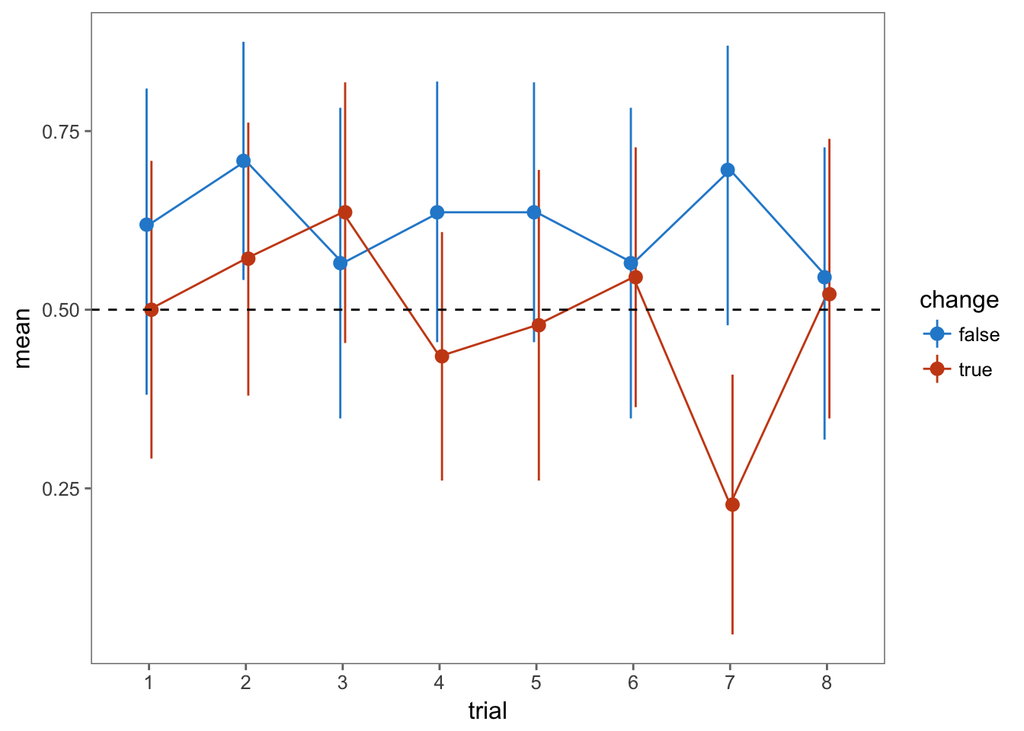

## By agent

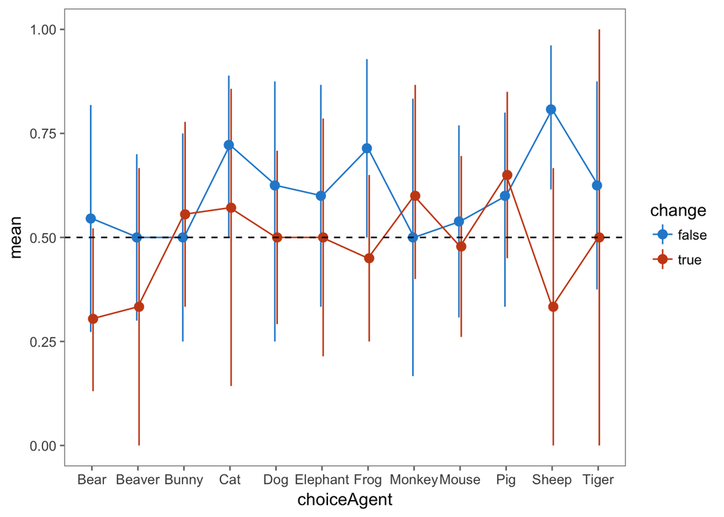